# Appendix

Seth Daly, Duc Vu, Bich Ha Nguyen, Ngoc Xuan Dung Nguyen

11/22/2021

#pdf_document

# 1 Import libraries

```r
library(MASS)
library(ggplot2)
library(dplyr)
library(tidyverse)
library(tidyr)
library(rqdatatable)
library(lubridate)
library(caret)
library(xts)
library(forecast)
library(tsbox)
library(TSstudio)
library(knitr)
library(kableExtra) # formatting table
library(gtools)
library(TSA)
library(tseries)
library(gridExtra)
library(ggpubr)
```

# 2 Data Cleaning

## 2.1 Read In

```r
droughtData <- read_csv("SPI.csv",
      col_names = c('SPI', 'Date', 'D0', 'D1', 'D2','D3', 'D4', 'SPI2', 'W0', 'W1', 'W2', 'W3','W4'), skip=1)
droughtData <- droughtData %>%
mutate(Date = ymd(substring(droughtData$'Date', 3)))
droughtData <- droughtData %>% filter(SPI > 0)
droughtData_D0 <- ts(droughtData$D0, start=c(1895, 9), end=c(2022, 3), freq=12)



### From 1895/09 to 1956/12
droughtData_1956 <- ts(droughtData_D0, start=c(1895, 9), end=c(1956, 12), freq=12)


### From 1957/01 to 2022/03
droughtData_2022 <- ts(droughtData_D0, start=c(1957, 1), end=c(2022, 3), freq=12)



### Train/Val Split from 1895/09 to 1956/12
train_1956 <- window(droughtData_1956, start = c(1895, 1), end=c(1955, 12))
val_1956 <- window(droughtData_1956, start = c(1956, 1), end=c(1956, 12))



### Train/Val Split from 1957/01 to 2022/03
train_2022 <- window(droughtData_2022, start = c(1957, 1), end=c(2020, 12))
val_2022 <- window(droughtData_2022, start = c(2021, 1), end=c(2022, 3))
```

# 3 EDA

## 3.1 Variable meaning (important)

Dry spell percentiles and corresponding USDM categories: D0 = At Least Abnormally Dry, D1 = At Least Moderate Drought, D2 = At Least Severe Drought, D3 = At Least Extreme Drought, D4 = At Least Exceptional Drought.

Note, categories are not mutually exclusive:

D0 + D1 + D2 + D3 + D4 != total amount of droughts!

D0 is total amount of droughts

All these values are percent of the country suffering this issue.

## 3.2 Structure

```r
head(droughtData_D0)
```

```
##       Jan  Feb Mar Apr May Jun Jul Aug  Sep  Oct  Nov  Dec
## 1895                                   37.9 59.4 51.4 50.0
## 1896 42.8 42.3
```

```r
tail(droughtData_D0)
```

```
##       Jan  Feb  Mar Apr May Jun Jul Aug Sep  Oct  Nov  Dec
## 2021                                        27.8 32.3 27.1
## 2022 25.9 34.9 34.5
```

```r
dim(droughtData_D0)
```

## 3.3 Old Data

```r
dim(droughtData_1956)
```

```r
head(droughtData_1956)
```

```
##       Jan  Feb Mar Apr May Jun Jul Aug  Sep  Oct  Nov  Dec
## 1895                                   37.9 59.4 51.4 50.0
## 1896 42.8 42.3
```

```r
tail(droughtData_1956)
```

```
##       Jul  Aug  Sep  Oct  Nov  Dec
## 1956 55.8 55.9 57.4 60.6 69.3 67.2
```

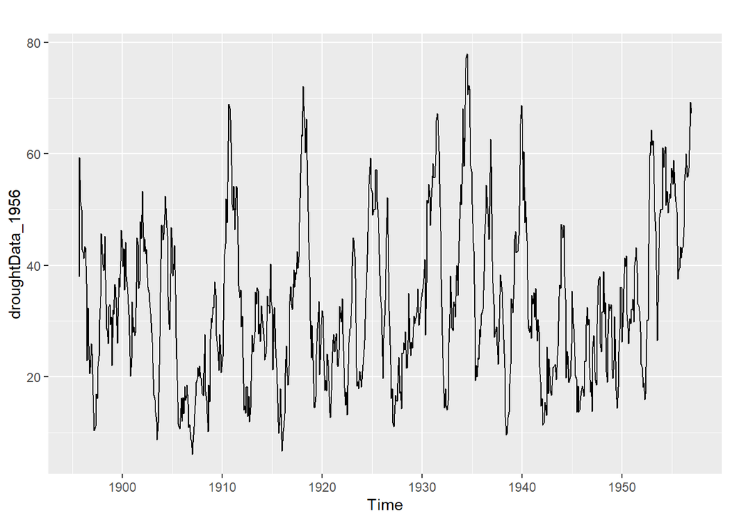

```r
autoplot(droughtData_1956)
```

## 3.4 New Data

```r
dim(droughtData_2022)
```

```r
head(droughtData_2022)
```

```
##       Jan  Feb  Mar  Apr  May  Jun
## 1957 37.9 59.4 51.4 50.0 42.8 42.3
```

```r
tail(droughtData_2022)
```

```
##       Jan  Feb  Mar Apr May Jun Jul Aug Sep  Oct  Nov  Dec
## 2021                                        29.4 41.0 35.5
## 2022 40.8 39.2 43.4
```

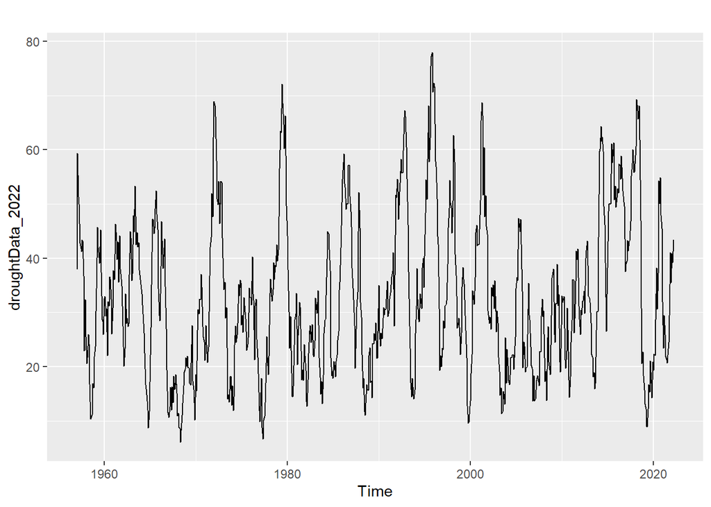

```r
autoplot(droughtData_2022)
```

## 3.5 All Data

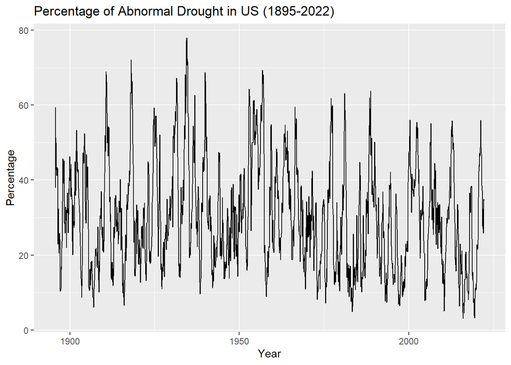

```r
## Autoplot of all data
ggplot2::ggplot(data=droughtData) +
geom_line(aes(x=Date, y=D0), size=0.4) +
    scale_color_manual(name="", values=c("Blue")) +
    labs(x="Year", y="Percentage")+
    ggtitle("Percentage of Abnormal Drought in US (1895-2022)") +
    theme(legend.position="bottom")
```

```r
## Dickey Fuller test
adf.test(droughtData$D0)
```

```
##
##  Augmented Dickey-Fuller Test
##
## data:  droughtData$D0
## Dickey-Fuller = -7.7419, Lag order = 11, p-value = 0.01
## alternative hypothesis: stationary
```

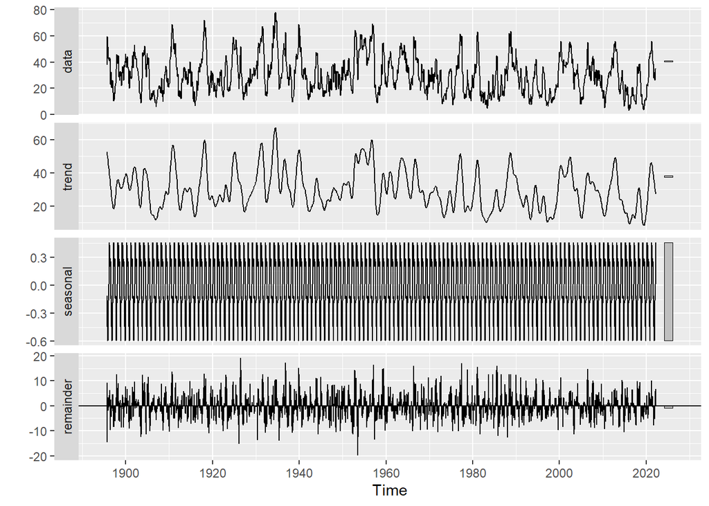

```r
## Trend & Seasonality + Remainder
       autoplot(stl(droughtData_D0, s.window = "periodic"))
```

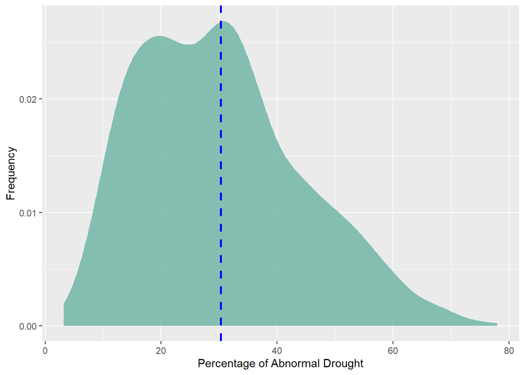

```r
       ## The distribution of D0 values
       ggplot(data = droughtData, aes(x=D0)) +
geom_density(fill="#69b3a2", color="#e9ecef", alpha=0.8) +
labs(x="Percentage of Abnormal Drought", y="Frequency") +
geom_vline(aes(xintercept=mean(D0)), color="blue", linetype="dashed", size=1)
```

# 4 Holt Winters Modeling

## 4.1 Holt Winters Modeling (Old D0)

### 4.1.1 Model Creation

```r
D0TS.full.old <- droughtData_1956
D0TS.full <- droughtData
D0TS.full.new <- droughtData_2022
D0TS.test.old <- val_1956
D0TS.train.old <- train_1956
D0TS.test.new <- val_2022
D0TS.train.new <- train_2022

D0.exp.old <- HoltWinters(D0TS.train.old, beta=FALSE, gamma=FALSE)
D0.trend.old <- HoltWinters(D0TS.train.old, gamma=FALSE)
D0.season.old <- HoltWinters(D0TS.train.old, beta=FALSE)
D0.hw.old <- HoltWinters(D0TS.train.old)
```

### 4.1.2 Model Predictions

```r
D0.for.exp.old <- forecast(D0.exp.old, h=length(D0TS.test.old))
D0.for.trend.old <- forecast(D0.trend.old, h=length(D0TS.test.old))
D0.for.season.old <- forecast(D0.season.old, h=length(D0TS.test.old))
D0.for.hw.old <- forecast(D0.hw.old, h=length(D0TS.test.old))
```

### 4.1.3 Visual Model Comparison

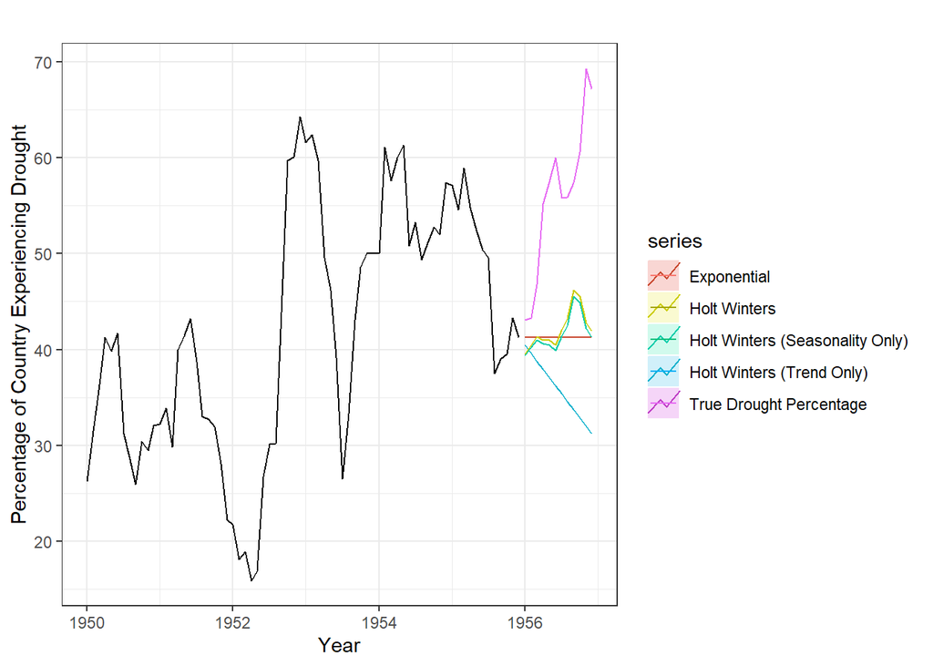

```r
autoplot(window(D0TS.train.old, start=c(1950,1))) +
  autolayer(D0.for.exp.old, PI=FALSE, series="Exponential") +
  autolayer(D0.for.trend.old, PI=FALSE, series="Holt Winters (Trend Only)") +
  autolayer(D0.for.season.old, PI=FALSE, series="Holt Winters (Seasonality Only) ") +
  autolayer(D0.for.hw.old, PI=FALSE, series="Holt Winters") +
  autolayer(D0TS.test.old, series="True Drought Percentage") +
  labs(x="Year", y="Percentage of Country Experiencing Drought") +
  theme_bw()
```

### 4.1.4 Compare Model Accuracy

```r
tab <- rbind(accuracy(D0.for.exp.old, D0TS.test.old)[2,2:3],
             accuracy(D0.for.trend.old, D0TS.test.old)[2,2:3],
             accuracy(D0.for.season.old, D0TS.test.old)[2,2:3],
             accuracy(D0.for.hw.old, D0TS.test.old)[2,2:3] )
rownames(tab) <- c("Exp Smoothing", "Holt (trend)", "HW (Season only)", "Holt Winters")
kable(tab)
```

|  | RMSE | MAE |
| --- | --- | --- |
| Exp Smoothing | 16.71502 | 14.70820 |
| Holt (trend) | 22.83255 | 20.19290 |
| HW (Season only) | 16.18484 | 14.38352 |
| Holt Winters | 15.68956 | 13.89157 |

From a combination of RMSE and MAE, we select the Holt Winters Model.

### 4.1.5 Visual Final Model Comparison

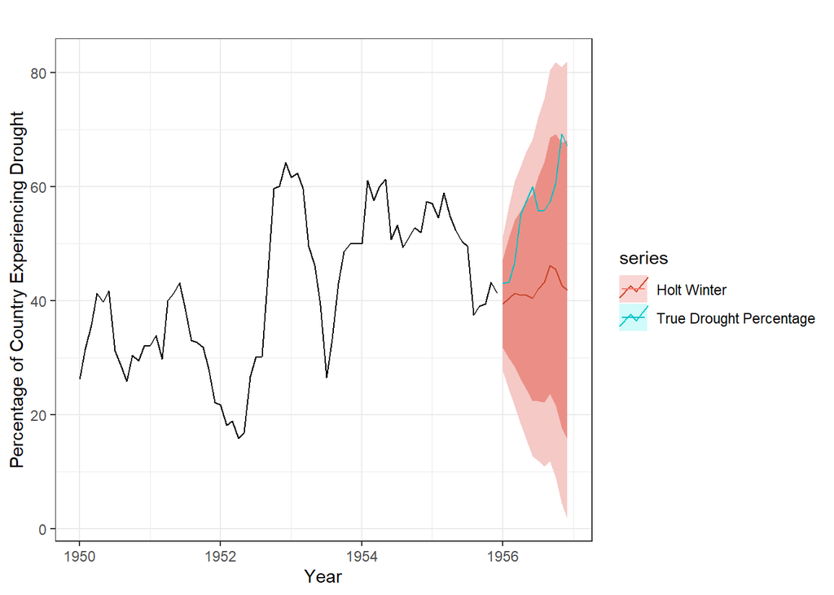

```r
autoplot(window(D0TS.train.old, start=c(1950,1))) +
  autolayer(D0.for.hw.old, PI=TRUE, series="Holt Winter") +
  autolayer(D0TS.test.old, series="True Drought Percentage") +
  labs(x="Year", y="Percentage of Country Experiencing Drought") +
  theme_bw()
```

## 4.2 Holt Winters Modeling (New D0)

### 4.2.1 Model Creation

```r
D0.exp.new <- HoltWinters(D0TS.train.new, beta=FALSE, gamma=FALSE)
D0.trend.new <- HoltWinters(D0TS.train.new, gamma=FALSE)
D0.season.new <- HoltWinters(D0TS.train.new, beta=FALSE)
D0.hw.new <- HoltWinters(D0TS.train.new)
```

### 4.2.2 Model Predictions

```r
D0.for.exp.new <- forecast(D0.exp.new, h=length(D0TS.test.new))
D0.for.trend.new <- forecast(D0.trend.new, h=length(D0TS.test.new))
D0.for.season.new <- forecast(D0.season.new, h=length(D0TS.test.new))
D0.for.hw.new <- forecast(D0.hw.new, h=length(D0TS.test.new))
```

### 4.2.3 Visual Model Comparison

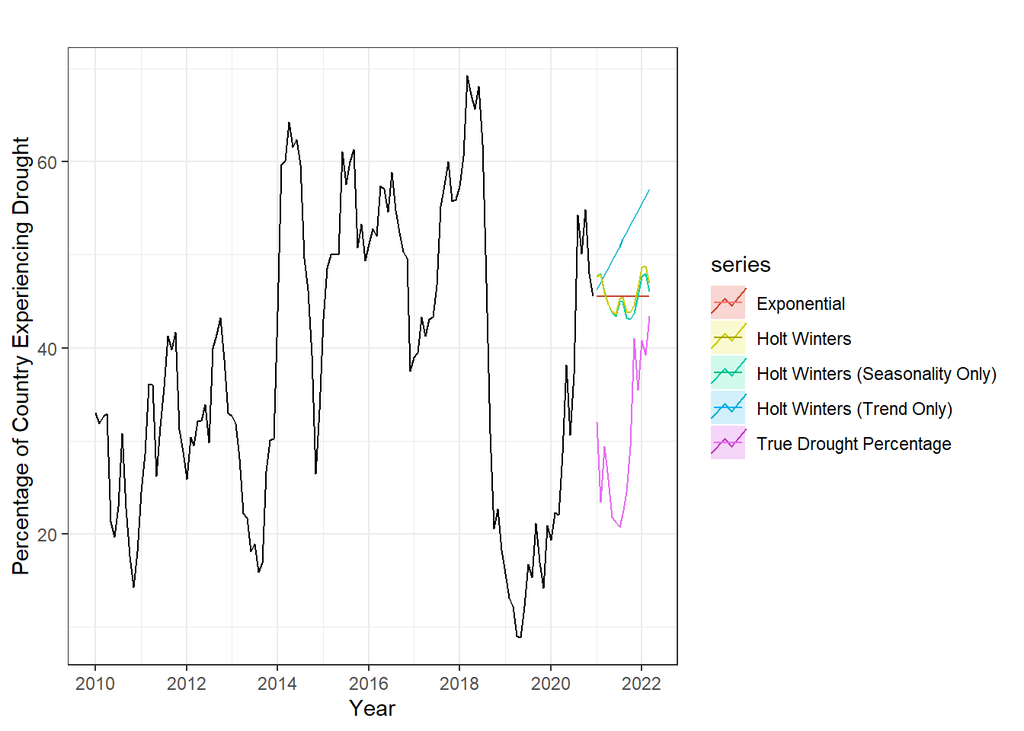

```r
autoplot(window(D0TS.train.new, start=c(2010,1))) +
  autolayer(D0.for.exp.new, PI=FALSE, series="Exponential") +
  autolayer(D0.for.trend.new, PI=FALSE, series="Holt Winters (Trend Only)") +
  autolayer(D0.for.season.new, PI=FALSE, series="Holt Winters (Seasonality Only) ") +
  autolayer(D0.for.hw.new, PI=FALSE, series="Holt Winters") +
  autolayer(D0TS.test.new, series="True Drought Percentage") +
  labs(x="Year", y="Percentage of Country Experiencing Drought") +
  theme_bw()
```

### 4.2.4 Compare Model Accuracy

```r
tab <- rbind(accuracy(D0.for.exp.new, D0TS.test.new)[2,2:3],
             accuracy(D0.for.trend.new, D0TS.test.new)[2,2:3],
             accuracy(D0.for.season.new, D0TS.test.new)[2,2:3],
             accuracy(D0.for.hw.new, D0TS.test.new)[2,2:3] )
rownames(tab) <- c("Exp Smoothing", "Holt (trend)", "HW (Season only)", "Holt Winters")
kable(tab)
```

|  | RMSE | MAE |
| --- | --- | --- |
| Exp Smoothing | 17.34107 | 15.47350 |
| Holt (trend) | 22.46057 | 21.62876 |
| HW (Season only) | 17.00088 | 15.34621 |
| Holt Winters | 17.31699 | 15.82228 |

From a combination of RMSE and MAE, we select the Holt Winters (Season Only) model.

### 4.2.5 Visual Final Model Comparison

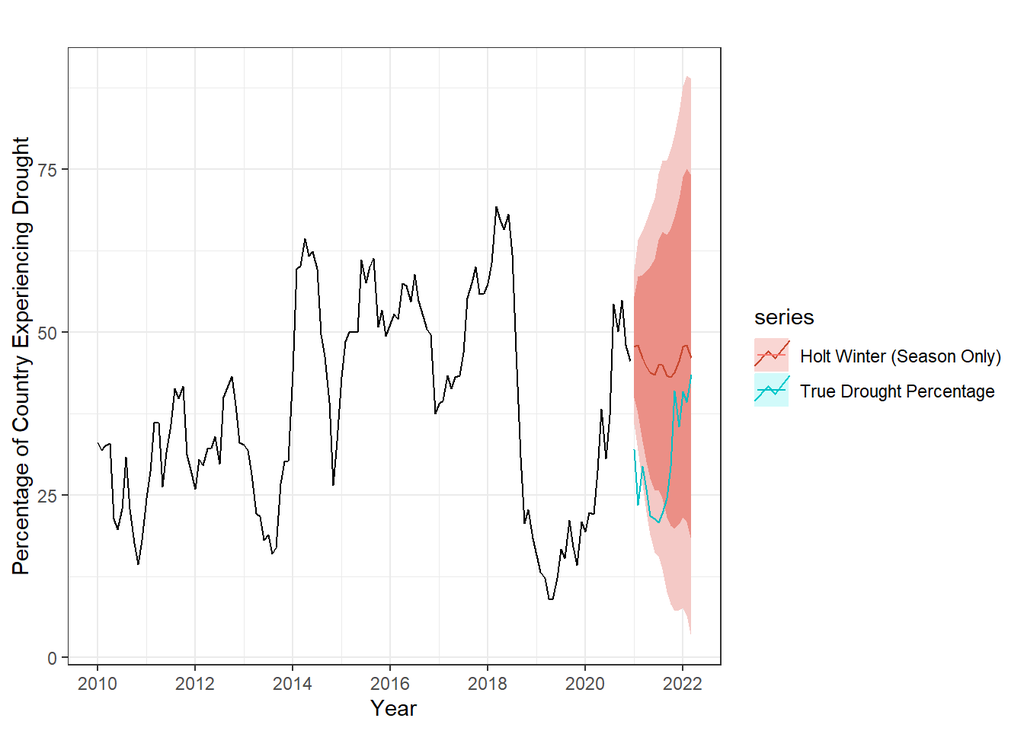

```r
autoplot(window(D0TS.train.new, start=c(2010,1))) +
  autolayer(D0.for.season.new, PI=TRUE, series="Holt Winter (Season Only)") +
  autolayer(D0TS.test.new, series="True Drought Percentage") +
  labs(x="Year", y="Percentage of Country Experiencing Drought") +
  theme_bw()
```

# 5 Cosine-Sine Model

## 5.1 Part 1: Old Period

### 5.1.1 Examine Data

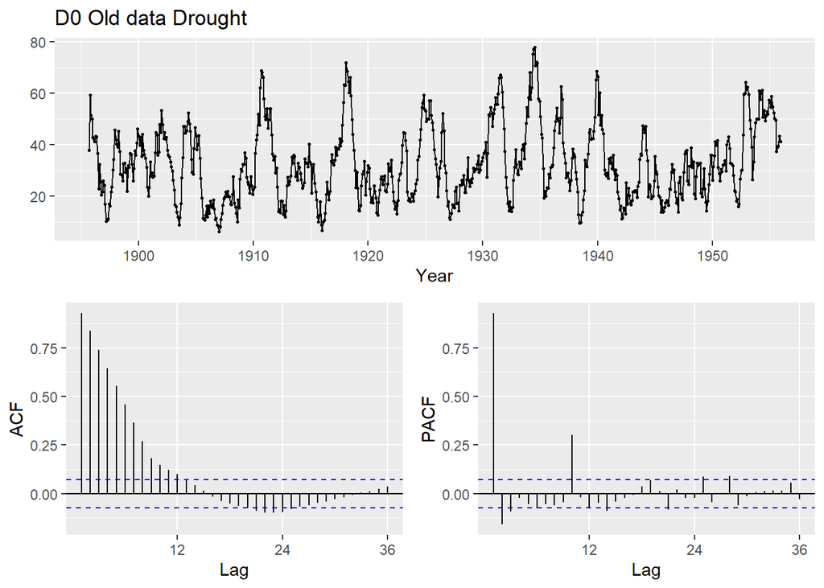

```r
train_1956 %>%
  ggtsdisplay(xlab="Year",
              main="D0 Old data Drought")
```

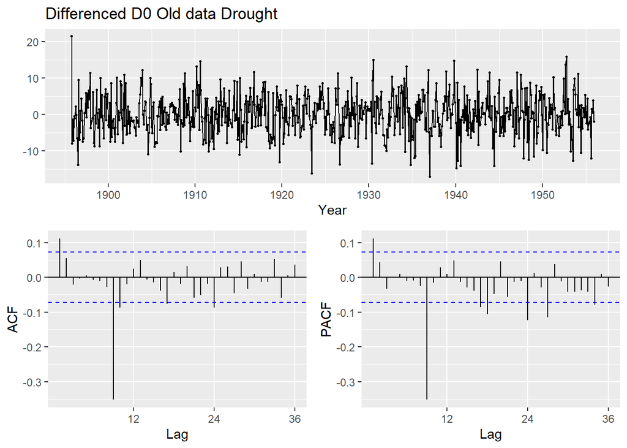

```r
train_1956 %>% diff() %>%
  ggtsdisplay(xlab="Year",
              main="Differenced D0 Old data Drought")
```

### 5.1.2 A. Periodogram

```r
f1956 = spec.pgram(train_1956, log="no", spans=c(9,9), detrend = TRUE)
```

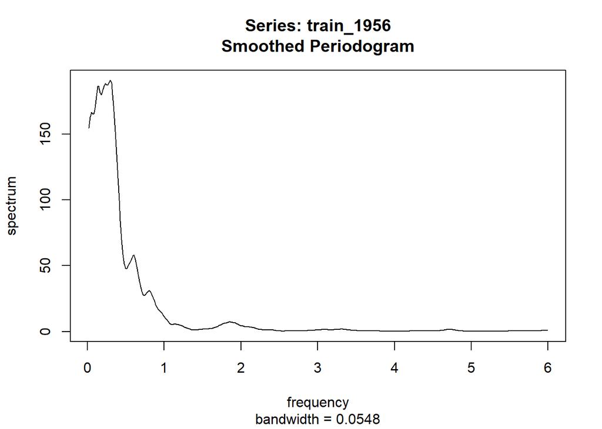

```r
f1956d = spec.pgram(diff(train_1956), log="no", spans=c(9,9), detrend = TRUE)
```

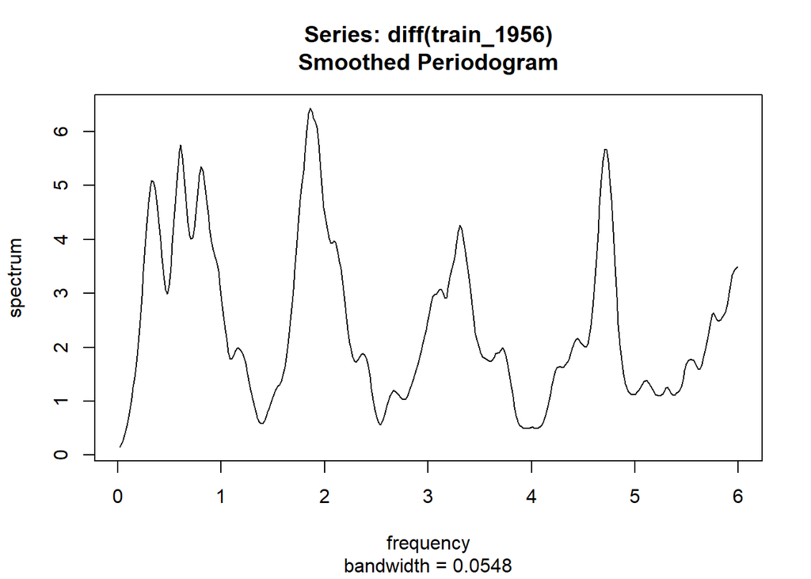

### 5.1.3 identify frequency

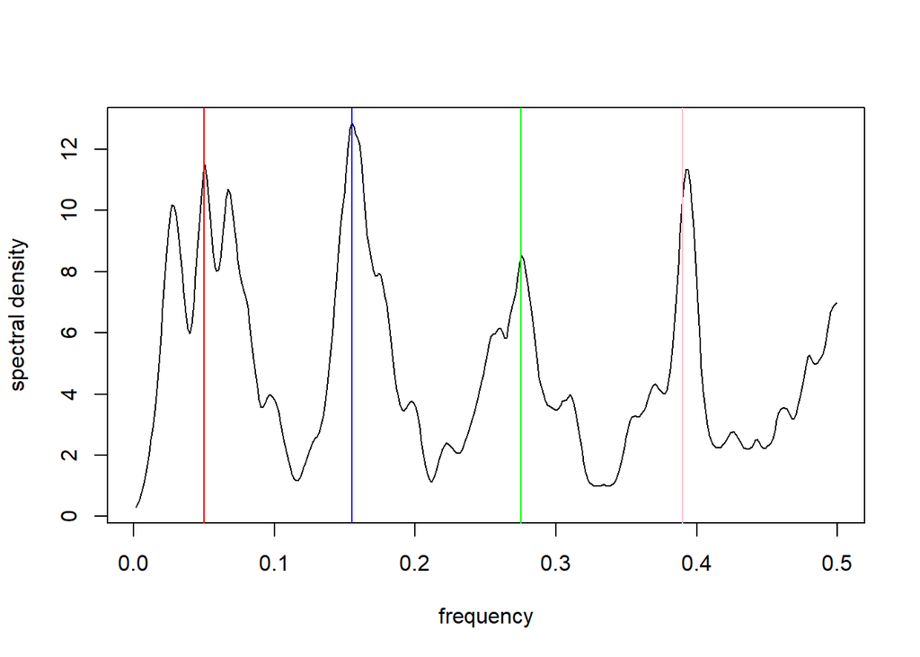

```r
del <- 12
spx1956 <- f1956d$freq/del
spy1956 <- 2*f1956d$spec
plot(spy1956~spx1956,xlab="frequency",ylab="spectral density",type="l")
#### frequencies: 0.04, 0.19, 0.25, 0.4, 0.5
abline(v=0.05, col="red")
abline(v=0.155, col="blue")
abline(v=0.275, col="green")
abline(v=0.39, col="pink")
```

### 5.1.4 Fit cosine-sine regression model

```r
w1=0.05
w2=0.155
w3=0.275
w4=0.39
```

```r
t= 1:length(diff(train_1956))
cs1=cos(2*pi*w1*t)
si1=sin(2*pi*w1*t)
cs2=cos(2*pi*w2*t)
si2=sin(2*pi*w2*t)
cs3=cos(2*pi*w3*t)
si3=sin(2*pi*w3*t)
cs4=cos(2*pi*w4*t)
si4=sin(2*pi*w4*t)
```

```r
fit1.1=lm(diff(train_1956)~t+cs1+si1+cs2+si2+cs3+si3+cs4+si4)
summary(fit1.1)
```

```
##
## Call:
## lm(formula = diff(train_1956) ~ t + cs1 + si1 + cs2 + si2 + cs3 +
##     si3 + cs4 + si4)
##
## Residuals:
##     Min      1Q  Median      3Q     Max
## -15.740  -3.285  -0.187   3.229  21.148
##
## Coefficients:
##               Estimate Std. Error t value Pr(>|t|)
## (Intercept) -0.0778667  0.4015994  -0.194   0.8463
## t            0.0002183  0.0009611   0.227   0.8204
## cs1          0.0796319  0.2834954   0.281   0.7789
## si1          1.1823879  0.2838280   4.166 3.48e-05 ***
## cs2          0.3047492  0.2836170   1.075   0.2830
## si2          0.4232468  0.2836537   1.492   0.1361
## cs3         -0.0463538  0.2837758  -0.163   0.8703
## si3         -0.2604369  0.2834911  -0.919   0.3586
## cs4         -0.1156349  0.2835960  -0.408   0.6836
## si4         -0.5838066  0.2836676  -2.058   0.0399 *
## ---
## Signif. codes:  0 '***' 0.001 '**' 0.01 '*' 0.05 '.' 0.1 ' ' 1
##
## Residual standard error: 5.393 on 713 degrees of freedom
## Multiple R-squared:  0.03539,    Adjusted R-squared:  0.02321
## F-statistic: 2.906 on 9 and 713 DF,  p-value: 0.002192
```

```r
fit1.2=lm(diff(train_1956) ~ si1-1)
summary(fit1.2)
```

```
##
## Call:
## lm(formula = diff(train_1956) ~ si1 - 1)
##
## Residuals:
##     Min      1Q  Median      3Q     Max
## -15.976  -3.229  -0.200   3.203  21.135
##
## Coefficients:
##     Estimate Std. Error t value Pr(>|t|)
## si1   1.1822     0.2838   4.166 3.47e-05 ***
## ---
## Signif. codes:  0 '***' 0.001 '**' 0.01 '*' 0.05 '.' 0.1 ' ' 1
##
## Residual standard error: 5.392 on 722 degrees of freedom
## Multiple R-squared:  0.02348,    Adjusted R-squared:  0.02213
## F-statistic: 17.36 on 1 and 722 DF,  p-value: 3.469e-05
```

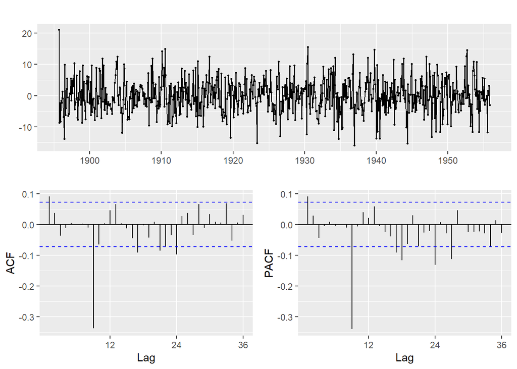

```r
resi1.1=fit1.2$residuals
temp1 <- ts(resi1.1, start=c(1895, 9), frequency=12)
temp1 %>% ggtsdisplay()
```

### 5.1.5 Fit with ARIMA

```r
t= 1:length(train_1956)
si1=sin(2*pi*w1*t)


fitp1.1 <- Arima(train_1956, order=c(2, 1, 2), xreg=cbind(si1))
fitp1.2 <- Arima(train_1956, order=c(2, 1, 0), xreg=cbind(si1))
fitp1.3 <- Arima(train_1956, order=c(0, 1, 2), xreg=cbind(si1))
fitp1.4 <- Arima(train_1956, order=c(1, 1, 1), xreg=cbind(si1))
fitp1.5 <- Arima(train_1956, order=c(2, 1, 1), xreg=cbind(si1))
fitp1.6 <- Arima(train_1956, order=c(1, 1, 2), xreg=cbind(si1))
```

```r
getAIC <- function(fit) {
   c(fit$aic, fit$aicc, fit$bic)
}

tab <- rbind(getAIC(fitp1.1), getAIC(fitp1.2), getAIC(fitp1.3),
             getAIC(fitp1.4), getAIC(fitp1.5), getAIC(fitp1.6))
tab
```

```
##          [,1]     [,2]     [,3]
## [1,] 4483.531 4483.648 4511.032
## [2,] 4501.783 4501.838 4520.116
## [3,] 4501.297 4501.353 4519.631
## [4,] 4502.310 4502.366 4520.644
## [5,] 4502.685 4502.768 4525.602
## [6,] 4502.998 4503.081 4525.915
```

```r
colnames(tab) <- c("AIC", "AICc", "BIC")
rownames(tab) <- c("ARIMA(2, 1, 2)",
                   "ARIMA(2, 1, 0)",
                   "ARIMA(0, 1, 2)",
                   "ARIMA(1, 1, 1)",
                   "ARIMA(2, 1, 1)",
                   "ARIMA(1, 1, 2)")
tab %>% kbl()%>%
  kable_material(c("striped", "hover"))
```

|  | AIC | AICc | BIC |
| --- | --- | --- | --- |
| ARIMA(2, 1, 2) | 4483.531 | 4483.648 | 4511.032 |
| ARIMA(2, 1, 0) | 4501.783 | 4501.838 | 4520.116 |
| ARIMA(0, 1, 2) | 4501.297 | 4501.353 | 4519.631 |
| ARIMA(1, 1, 1) | 4502.310 | 4502.366 | 4520.644 |
| ARIMA(2, 1, 1) | 4502.685 | 4502.768 | 4525.602 |
| ARIMA(1, 1, 2) | 4502.998 | 4503.081 | 4525.915 |

### 5.1.6 Model Accuracy

```r
t1.test = 1:length(val_1956)
si1.t=sin(2*pi*w1*t1.test)

d0_1.validation <- forecast(fitp1.1, xreg=cbind(si1.t))
acc1 <- accuracy(d0_1.validation, val_1956)
acc1
```

```
##                        ME      RMSE       MAE      MPE     MAPE      MASE
## Training set  0.005106032  5.324964  4.153248 -1.62019 14.69447 0.2727863
## Test set     14.155377733 16.188099 14.155378 23.67866 23.67866 0.9297285
##                    ACF1 Theil's U
## Training set 0.03302857        NA
## Test set     0.67422171  3.547923
```

```r
acc1[2, 2:3]
```

```
##     RMSE      MAE
## 16.18810 14.15538
```

```r
d0_1.validation2 <- forecast(fitp1.5, xreg=cbind(si1.t))
acc2 <- accuracy(d0_1.validation2, val_1956)
acc2
```

```
##                        ME      RMSE       MAE      MPE     MAPE      MASE
## Training set  0.003675399  5.405023  4.207806 -1.55945 14.91410 0.2763697
## Test set     14.775112949 16.775857 14.775113 24.78731 24.78731 0.9704329
##                     ACF1 Theil's U
## Training set -0.01290986        NA
## Test set      0.66896745  3.678007
```

### 5.1.7 Visual plot

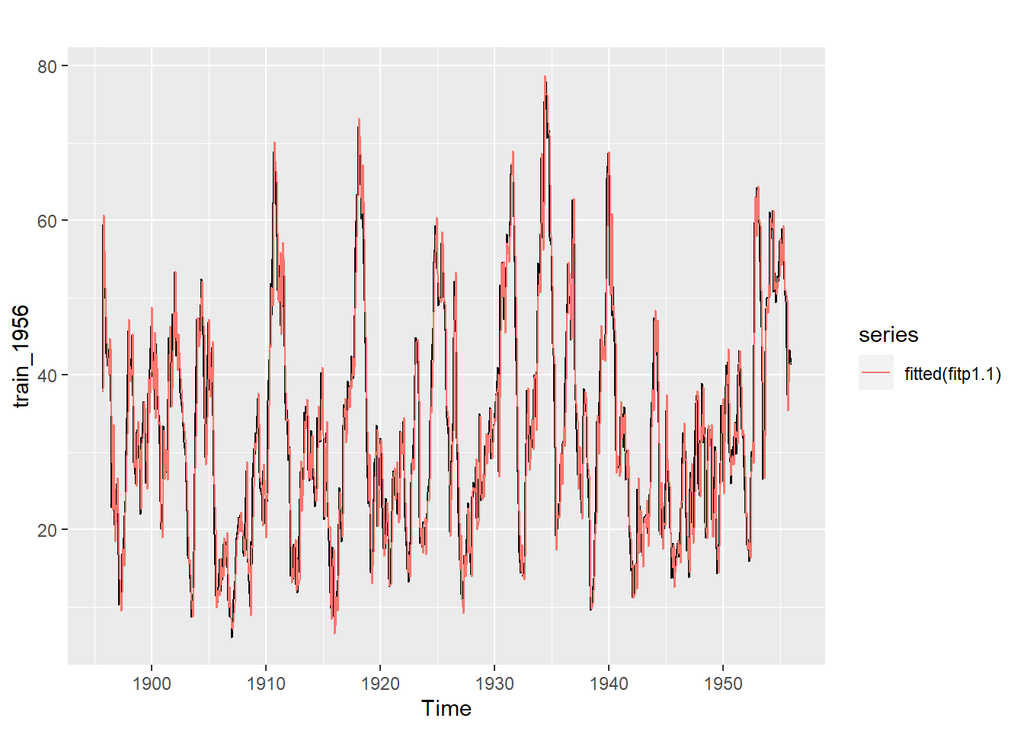

```r
autoplot(train_1956) +
  autolayer(fitted(fitp1.1))
```

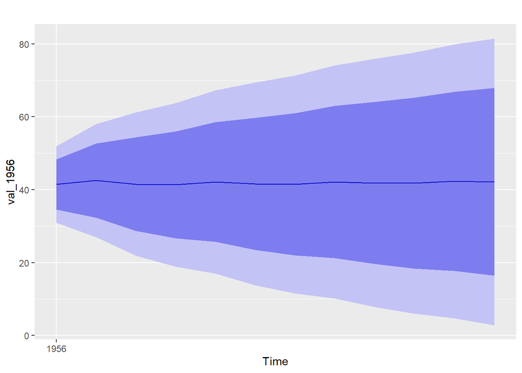

```r
autoplot(val_1956) +
  autolayer(d0_1.validation)
```

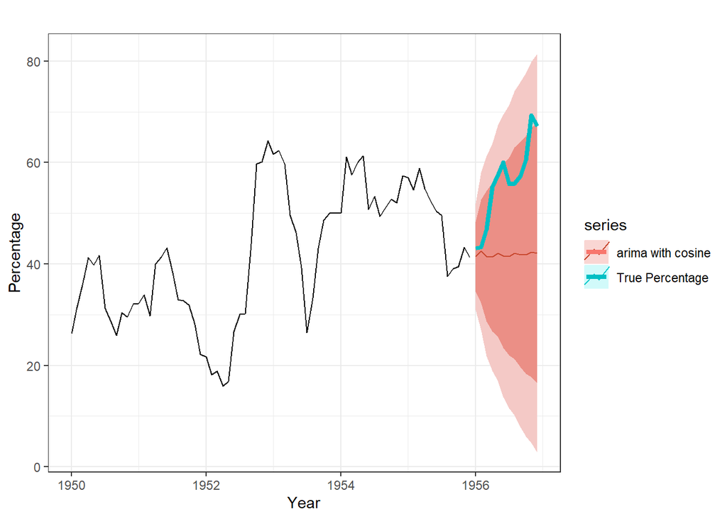

```r
autoplot(window(train_1956, start=c(1950,1))) +
  autolayer(d0_1.validation, series="arima with cosine") +
  autolayer(val_1956, series="True Percentage", size=1.5) +
  labs(x="Year", y="Percentage") +
  theme_bw()
```